# Machine Learning for MHC I peptide classification

Using the R interface to Keras / TensorFlow

Alistair Bailey

1st May 2018

# Overview

This notebook is based upon a blog post by Leon Eyrich Jessen: https://tensorflow.rstudio.com/blog/dl-for-cancer-immunotherapy.html

Leon’s blog shows how to build a deep learning model that classifies the strength of binding of different peptides to a single MHC I allotype (HLA-A*02:01).

Machine learning in general attempts to find transformations of input data into more useful representations of that data to solve a problem.

Deep learning does this by successive data transformations via layers, the depth referring to the number of layers of transformations, not the extent of insight gained.

This layered approach is sometimes referred to as a neural network, however as François Chollet, one of the authors of [Deep Learning with R](https://www.manning.com/books/deep-learning-with-r) tweeted:

[figure not shown]

Here I present a variation on Leon’s theme after I was kindly invited to present at the Computational Biology Club Meeting at the University of Southampton on April 25th 2018.

I took the invitation as an opportunity to learn a bit more about how peptide prediction tools such as [NetMHC](http://www.cbs.dtu.dk/services/NetMHC/) work.

What follows is a toy model that attempts to classify peptides from my some of my experiments according to one of five MHC class I allotypes present in the cells I use.

The repository with all the code and datasets is here: https://github.com/ab604/mhc_tensorflow

## Some background

MHC I allotypes (allo means other) refers to proteins expressed by the most diverse gene in the human genome. We each have up to six MHC I gene variants, or alleles, depending upon those carried by our parents and therefore almost all our cells express up to six MHC I allotype proteins: Two A, two B and two C allotypes.

MHC I proteins have evolved to sample fragments of other proteins from the complement of proteins inside our cells and present them to our immune system at the cell surface. These small fragments are called peptides and in MHC I processing, the predominant length of a peptide MHC I selects is 9 amino acids.

Pamela Bjorkman solved the first MHC I structure in 1987 and the peptide can be seen bound in the picture below in red.

[figure not shown]

Thousands of MHC I molecules continuously select and bind peptides, presenting them at the cell surface as way of communicating to our immune system what is going on inside our cells. This is called antigen processing and presentation.

If a cell is healthy, the MHC I molecules and peptides presented mean that the immune system does nothing. But if a virus infects our cells, or if a tumour develops, then the peptides presented may include those derived from viral or tumour specific proteins and the immune system will attack and kill these cells.

A more detailed graphical description of our current understanding is show below:

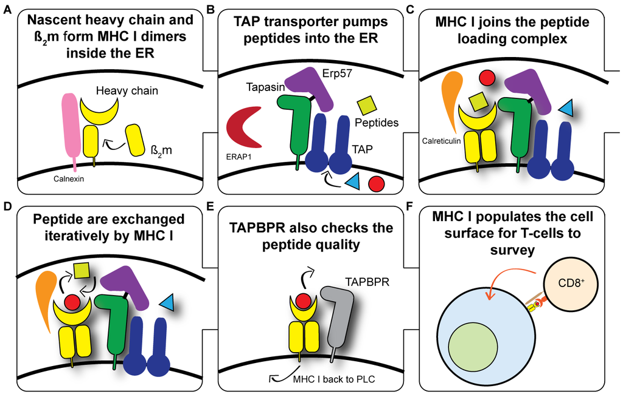

**MHC I antigen processing, doi: 10.12688/f1000research.10474.1**

In circumstances where the immune system is unable to clear disease, the identification of peptides associated with both a strong immune response and specific MHC I allotypes would be of great use in creating vaccines that could paint diseased cells as targets.

However the methods we use to observe peptides and MHC I molecules experimentally means that the MHC I molecules and their peptides become separated and we don’t easily know how to match peptides to their MHC I allotypes. Hence I have used deep learning to try and classify the peptides according to which allotypes they bind.

## Key takeaways

- The greatest amount of work is in obtaining and tidying a development dataset.
- Machine Learning can be deployed from R or Python using the Keras API with minimal code (20 lines or so)
- Modelling complements and informs judgement. It is not an alternative to it. (This probably should go without saying, but anecdotally I notice colleagues requesting a black box where data goes in and concrete answers come out.)

## Additional resources I used for this notebook

J.J. Allaire & François Chollet : https://www.manning.com/books/deep-learning-with-r

Leon Eyrich Jessen : https://tensorflow.rstudio.com/blog/dl-for-cancer-immunotherapy.html

R Keras : https://keras.rstudio.com/

Python Keras : https://keras.io/

TensorFlow : https://www.tensorflow.org/

Andrew Ng : https://www.coursera.org/learn/machine-learning

Datacamp : https://www.datacamp.com/tracks/machine-learning

Rmarkdown : https://rmarkdown.rstudio.com

# Allotype classification model

As this is a supervised learning approach, I first needed some data with which to train the model. As I’m fortunate to work in with human cell lines there is a curated database of experimentally derived peptides called the [immune epitope database](http://www.iedb.org/) (IEDB). Full details on the curation methodology can be found [here](http://curationwiki.iedb.org/wiki/index.php/Curation_Manual2.0).

In humans the nomenclature for MHC I allotypes begins with the acronym HLA, and as I mentioned earlier we can have two A, two B and two C HLA types in our cells. I know from our own HLA typing of the cells I sue that there are HLA-A*31 homozygous (meaning both A genes are the same), HLA-B*40 and HLA-B*51, and HLA-C*03 and HLA-C*15.

Hence I needed to obtain identified peptides for these five allotypes from the IEDB as training data.

## Obtaining the IEDB peptide data

Peptide data can be downloaded most simply by using there web interface, although the current database can also be exported as a [SQL database](http://www.iedb.org/database_export_v3.php) for use too.

Here I used the web interface and for each allotype I entered the allotype of interest into the MHC restriction box as shown in the image below.

[figure not shown]

**Choosing a MHC allotype**

I then exported the results as CSV files into my data directory:

[figure not shown]

**Downloading the peptides**

## Setting up R

As per [Leon’s prerequisites](https://tensorflow.rstudio.com/blog/dl-for-cancer-immunotherapy.html#prerequisites) I installed and set-up Keras and the associated tools I need. I also set a seed for reproducibility of results.

```r
#install.packages("devtools")
#devtools::install_github("leonjessen/PepTools")
#devtools::install_github("omarwagih/ggseqlogo")
# Load packages
library(keras)
library(tidyverse)
library(PepTools)
library(janitor)
set.seed(1458) # Set seed for reproducibility
```

## Tidying the IEDB data

After a bit of manual inspection of the CSV files I wrote a small function for reading and tidying each file.

It’s a bit messy but essentially it skips the header, takes out only the peptide, adds some new variable labels we need, removes unwanted characters from the peptide sequence, and filters the rows for peptides of only 9 amino acids in length.

The new labels are characters and integer values for the allotypes.

```r
## Function to tidy iedb peptide data
## Takes in file_path to csv file and MHC I allotype name label and number
tidy_peptides <- function(file_path,allotype,allotype_num) {

  tidy_dat <- read_csv(file_path, skip = 1, col_types = cols()) %>%
    # Filter peptide rows
    filter(!str_detect(Description,"[lX]") &
             `Object Type` == "Linear peptide") %>%
    # Add new variables
    mutate(length = str_count(Description), # Add length
         label_chr = allotype, # Label allotype
         label_num = allotype_num, # Add integer for allotype
         # Remove any extras strings
         peptide = str_replace_all(Description,"\\(.*?\\)", "")) %>%
    # Filter only 9mers
    filter(length == 9 ) %>%
    # Keep only the peptide and labels
    select(peptide, label_chr, label_num)

  return(tidy_dat)
}
```

I then use the function like so to read in the individual allotype data, and then bind it into a single data set.

```r
# Load and tidy the data for five MHC I allotypes
a31_train <- tidy_peptides("../data/iedb/iedb_a31_peptides.csv","A31",0L)
b40_train <- tidy_peptides("../data/iedb/iedb_b40_peptides.csv", "B40", 1L)
b51_train <- tidy_peptides("../data/iedb/iedb_b51_peptides.csv", "B51", 2L)
c03_train <- tidy_peptides("../data/iedb/iedb_c03_peptides.csv", "C03", 3L)
c15_train <- tidy_peptides("../data/iedb/iedb_c15_peptides.csv", "C15", 4L)

# Bind into a single tibble and label as training data
iedb_peps <- bind_rows(a31_train,b40_train,b51_train,c03_train,c15_train)

# Look at a sample of 20
iedb_peps %>% sample_n(20)
```

| peptide | label_chr | label_num |
| --- | --- | --- |
| FPISPIETV | B51 | 2 |
| FALPAYHTL | C03 | 3 |
| AENHFLVGL | B40 | 1 |
| WEIQQVVDA | B40 | 1 |
| AENPFLTHL | B40 | 1 |
| WLSMTDEMR | A31 | 0 |
| VPVSLVNSI | B51 | 2 |
| SRLGIVVLR | A31 | 0 |
| QQLEDIFMR | A31 | 0 |
| GSYVFENTV | C15 | 4 |

[output cut: 10 more lines]

To avoid bias from having peptide groups of different sizes for each allotype I sampled 1000 for each allotype to create a regularised data set.

```r
# Count the number of peptides for each allotype
iedb_peps %>% group_by(label_chr) %>% tally()
```

| label_chr | n |
| --- | --- |
| A31 | 1852 |
| B40 | 1655 |
| B51 | 2193 |
| C03 | 1013 |
| C15 | 1749 |

```r
# Balance the dataset by sampling 1000 peptides for each allotype
iedb_peps_reg <- iedb_peps %>% group_by(label_chr) %>% sample_n(1000)

# Check the number of peptides again
iedb_peps_reg %>% group_by(label_chr) %>% tally()
```

| label_chr | n |
| --- | --- |
| A31 | 1000 |
| B40 | 1000 |
| B51 | 1000 |
| C03 | 1000 |
| C15 | 1000 |

```r
# Look at a sample of 20
iedb_peps_reg %>% ungroup() %>% sample_n(20)
```

| peptide | label_chr | label_num |
| --- | --- | --- |
| ATISYILTL | C03 | 3 |
| FPMSPVTSV | B51 | 2 |
| FAFRNFLYL | C03 | 3 |
| IIVDIFHGL | C03 | 3 |
| YLFNQHIKK | A31 | 0 |
| AGKPAFMGR | A31 | 0 |
| MASVEPHWI | B51 | 2 |
| TAVPYFSNL | C03 | 3 |
| IATEIILEI | B51 | 2 |
| VVNGRVLEL | C15 | 4 |

[output cut: 10 more lines]

## Split the IEDB data into training and test sets

Having tidied the IEDB data, I next split it into 80% training and 20% test data like so:

```r
# Take 80% of subset of iedp peptides for training
smp_size <- floor(0.80 * nrow(iedb_peps_reg)) # Find sample size
train_idx <- sample(seq_len(nrow(iedb_peps_reg)), smp_size) # Get indices
# Subset data and label as training
peps_train <- iedb_peps_reg[train_idx,] %>%
  mutate(data_type = "train")

# Extract the other 20% using the inverse of the index for the testing
peps_test <- iedb_peps_reg[-train_idx,] %>%
  mutate(data_type = "test")

# Bind into one data set
pep_dat <- bind_rows(peps_train,peps_test)
# Check the the numbers of peptides
pep_dat %>% group_by(label_chr, data_type) %>% tally()
```

| label_chr | data_type | n |
| --- | --- | --- |
| A31 | test | 214 |
| A31 | train | 786 |
| B40 | test | 197 |
| B40 | train | 803 |
| B51 | test | 202 |
| B51 | train | 798 |
| C03 | test | 181 |
| C03 | train | 819 |
| C15 | test | 206 |
| C15 | train | 794 |

```r
# Look at a sample of pep_dat
pep_dat %>% ungroup() %>% sample_n(10)
```

| peptide | label_chr | label_num | data_type |
| --- | --- | --- | --- |
| NAINKLPTV | B51 | 2 | train |
| REPETTVVL | B40 | 1 | test |
| DTIVSRSSR | A31 | 0 | train |
| AEGPYKIIL | B40 | 1 | train |
| YPQAVFLEV | B51 | 2 | train |
| MPYVFTLLF | B51 | 2 | train |
| MRYVASYLL | B51 | 2 | train |
| AEFKTKYKL | B40 | 1 | train |
| VPYPRIHFP | B51 | 2 | train |
| TVIGAFWHL | C03 | 3 | train |

## Encoding the peptides

[Where did the BLOSUM62 alignment score matrix come from?](https://www.nature.com/articles/nbt0804-1035) The linked paper gives a detailed explanation, but the aim of BLOSUM62 matrix is to discover if protein sequences are related or not by creating a score that reflects that.

By observing lots of protein sequences the expected frequencies of each amino acid can be obtained. Given these sequences, a matrix of 20 amino acids by 20 amino acids can be created with elements containing the log odds ratio of each amino acid combination in terms of the ratio of the observed amino and the expected frequency.

This score then is a numerical way of thinking about the biochemical similarity between amino acids and therefore the likelihood of substituting one amino acid for another at any position a protein sequence.

Using the BLOSUM62 matrix enables the encoding the peptides as a way of generalising each peptide sequence from its specific sequence to a general sequence such that for example, a leucine (L) is scored as similar to isoleucine (I) and dissimilar to a lysine (K). This generalisation enables the algorithm to classify similar peptides more easily.

This approach first was described in one of the key papers describing [NetMHC](http://www.cbs.dtu.dk/services/NetMHC/) :

Reliable prediction of T-cell epitopes using neural networks with novel sequence representations. Nielsen M, Lundegaard C, Worning P, Lauemoller SL, Lamberth K, Buus S, Brunak S, Lund O. Protein Sci., (2003) 12:1007-17

PubMed: [12717023](http://www.ncbi.nlm.nih.gov/entrez/query.fcgi?cmd=Retrieve&db=PubMed&list_uids=12717023&dopt=Abstract)

Using the [PepTools package](https://github.com/leonjessen/PepTools), in practice each amino acid in the peptide sequence is transformed into a 2D tensor of 9 X 20 integers, and all the training peptides together form a 3D tensor comprised of 4000 2D tensors.

There is a cost here of more computation, or of learning unwanted patterns.

Below is an example of an encoded peptide with the peptide sequence on the y-axis, the standard amino acid alphabet on x-axis and the score representing the likelihood of switching the peptide amino acid to different amino acid in the alphabet represented by the shading.

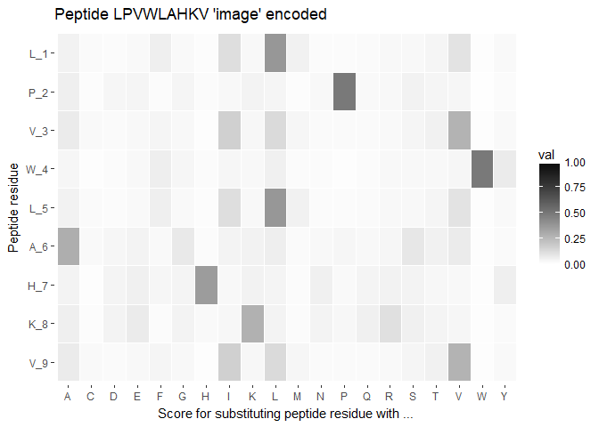

## Transform data for Keras/TensorFlow model

Following the encoding procedure described in the previous section, the peptide data is prepared as per [Leon’s method](https://tensorflow.rstudio.com/blog/dl-for-cancer-immunotherapy.html#data-preparation).

The things to note in the code here is that the training and test data are both prepared as arrays. The input shape of 180 is given by the encoding of 9 amino acid peptides in terms of the 20 amino acid alphabet, whilst I am aiming to classify five MHC allotypes.

During training, the training data is split again into training and validation targets. This is how the model learns as it iterates through the input data multiple times to fit the model parameters.

```r
# Input shape: 9 peptides x 20 amino acids = 180
input_shape <- 180
# Output classes : 5 MHC I allotypes
num_classes <- 5

# Setup training data
target  <-'train'
x_train <- pep_dat %>% filter(data_type==target) %>% pull(peptide) %>% pep_encode
y_train <- pep_dat %>% filter(data_type==target) %>% pull(label_num) %>% array

# Setup test data
target <- 'test'
x_test <- pep_dat %>% filter(data_type==target) %>% pull(peptide) %>% pep_encode
y_test <- pep_dat %>% filter(data_type==target) %>% pull(label_num) %>% array

# Reshape into arrays
x_train <- array_reshape(x_train, c(nrow(x_train), input_shape))
x_test  <- array_reshape(x_test,  c(nrow(x_test),  input_shape))
y_train <- to_categorical(y_train, num_classes)
y_test  <- to_categorical(y_test,  num_classes)
```

## Define the model

The Keras framework provides a way to build and implement deep learning models with minimal code given the data preparation. TensorFlow is the numerical library for perfomring the calculations (other libraries can be used with Keras).

As I’m creating a classification model I need to define a `keras_model_sequential()`, to which the layers are added.

Just like being in the lab, it all gets a bit empirical at this point and there aren’t clear rules as to how many layers to use, but I adopted the “start simple” approach and used [Leon’s model](https://tensorflow.rstudio.com/blog/dl-for-cancer-immunotherapy.html#defining-the-model) following [a bit of reading](https://www.manning.com/books/deep-learning-with-r) about activation functions and how to avoid over-fitting using dropout layers.

The danger of over-fitting is that the model will perform well on the training data and then poorly on data the model has never seen.

What the model is ultimately trying to do is fit the 49,325 parameters that will transform the encoded peptide sequences successfully into the five MHC allotype classes to which they belong.

Using Keras we only need this much code to define the model:

```r
# relu activation : function for performing non-linear transformations
# expanding hypothesis space.
# Dropout layer : helps deal with overfitting. Drops features from output layer.

# Initialize sequential model
model <- keras_model_sequential()

# Build architecture
model %>%
  layer_dense(units  = 180, activation = 'relu', input_shape = 180) %>%
  layer_dropout(rate = 0.4) %>%
  layer_dense(units  = 90, activation  = 'relu') %>%
  layer_dropout(rate = 0.3) %>%
  layer_dense(units  = 5, activation   = 'softmax') # Return probability scores
                                                    # for each class

# Look at the model structure
model
```

```
## Model
## ___________________________________________________________________________
## Layer (type)                     Output Shape                  Param #
## ===========================================================================
## dense_1 (Dense)                  (None, 180)                   32580
## ___________________________________________________________________________
## dropout_1 (Dropout)              (None, 180)                   0
## ___________________________________________________________________________
## dense_2 (Dense)                  (None, 90)                    16290
## ___________________________________________________________________________
## dropout_2 (Dropout)              (None, 90)                    0
## ___________________________________________________________________________
## dense_3 (Dense)                  (None, 5)                     455
## ===========================================================================
## Total params: 49,325
## Trainable params: 49,325
## Non-trainable params: 0
## ___________________________________________________________________________
```

## Compile and train the model

Having defined the model we next compile it by defining how the algorithm measures the difference between the input data and the validation targets in each iteration (the `loss`),how the parameters are optimized, and how success in each iteration is measured:

```r
# Compile model
model %>% compile(
  loss      = 'categorical_crossentropy', # Feedback loss function, distance.
  optimizer = optimizer_rmsprop(),        # Gradient descent rules
  metrics   = c('accuracy'))           # How often we match the target
```

Then we train the model, saving the output to `history`, by feeding the training data set 10 times (`epochs`) through the model in batches of 80 peptides at a time, keeping 20% for validation targets to assess the fit.

```r
# Train the model
history <- model %>% fit(
  x_train, y_train,
  epochs           = 10,   # 10 iterations over all training data
  batch_size       = 80,   # 80 peptides per batch
  validation_split = 0.2)  # Use 20% of training data for validation targets
```

Plotting the `history` we can see why I chose 10 epochs. The `loss` between training and has reached a minimum, and the accuracy is in danger of over-fitting in further iterations as the training accuracy overtakes the validation accuracy.

I’ve achieved about 90% accuracy in classifying these peptides in training.

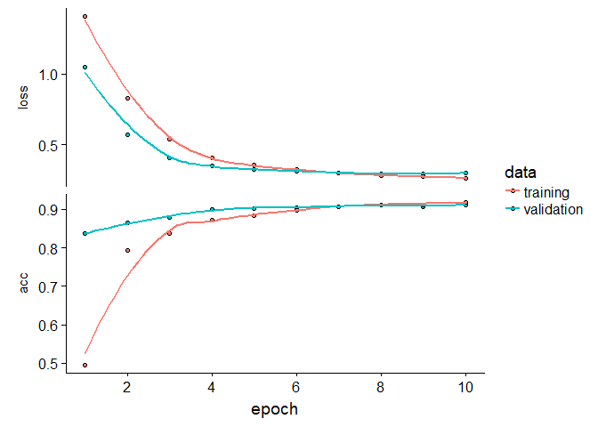

```r
plot(history)
```

## Evaluation of the model using the IEDB test set

Now I use the test data, which the model hasn’t seen before, to evaluate the performance using [Leon’s code.](https://tensorflow.rstudio.com/blog/dl-for-cancer-immunotherapy.html#training-and-evaluation)

Here we can see that the model achieves over 90% accuracy at classifying which allotype the test peptides belong to.

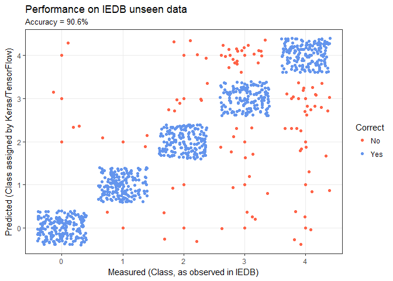

```r
# Leon's code for plotting performance
perf    <-  model %>% evaluate(x_test, y_test)
acc     <-  perf$acc %>% round(3) * 100
y_pred  <-  model %>% predict_classes(x_test)
y_real  <-  y_test %>% apply(1,function(x){ return( which(x==1) - 1) })
results <-  tibble(y_real  = y_real %>% factor,
                 y_pred  = y_pred %>% factor,
                 Correct = ifelse(y_real == y_pred,"yes","no") %>% factor)

title = 'Performance on IEDB unseen data'
xlab  = 'Measured (Class, as observed in IEDB)'
ylab  = 'Predicted (Class assigned by Keras/TensorFlow)'
results %>%
  ggplot(aes(x = y_pred, y = y_real, colour = Correct)) +
  geom_point() +
  ggtitle(label = title, subtitle = paste0("Accuracy = ", acc,"%")) +
  xlab(xlab) +
  ylab(ylab) +
  scale_color_manual(labels = c('No', 'Yes'),
                     values = c('tomato','cornflowerblue')) +
  geom_jitter() +
  theme_bw()
```

## Comparison of predictions for my experimental data

I’m excluding much of the code here, but I wanted to then see how this toy model compared to [NetMHC](http://www.cbs.dtu.dk/services/NetMHC/) the most widely used peptide prediction server.

NetMHC seeks to predict the binding affinity of peptides *to a given allotype or allotypes*. So unlike my model the user decides which allotype(s) the peptides are to be tested against.

I took 1,000 peptides that I’d isolated in the lab using proteomics methods and used NetMHC to predict whether they’d bind or not to any of the five MHC allotypes in my cell line. I used the rank cut-off of 2% for a predicted binder and in this way classified the peptides according to allotype in terms of whether they were predicted to bind or not.

The same 1,000 peptides were encoded as for the training data as `h_dat`and the model used to predict their allotypes:

```r
model %>% predict_classes(h_dat)
```

I then merged the model and NetMHC predictions to compare their classification of my peptides.

In the plot below, the model MHC allotype classification is on the x-axis and the NetMHC classification is on the y-axis. There is an additional class to my model of “NB” where NetMHC predicts no binding of the peptide as opposed to a different allotype.

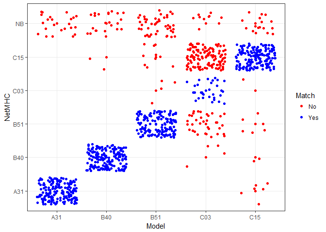

```r
validation_peps %>%
  ggplot(aes(x = label_chr.x, y = label_chr.y, colour = Match)) +
  geom_point() +
  xlab("Model") +
  ylab("NetMHC") +
  scale_color_manual(values = c('red','blue')) +
  geom_jitter() +
  theme_bw()
```

The data can also be represented in a table and corresponding with the figure, we can see that both predictions agree well for some allotypes i.e. HLA-A*31, but less well for others i.e. HLA-C*03.

Why might this be?

```r
# Compare peptide predictions between model and NetMHC
validation_peps %>%
  group_by(label_chr.x, label_chr.y) %>%
  summarise(N_peptides = n()) %>%
  mutate(Percent = round(N_peptides/sum(N_peptides)*100, 1)) %>%
  arrange(desc(Percent)) %>%
  select(Model = label_chr.x,NetMHC = label_chr.y, N_peptides, Percent)
```

| Model | NetMHC | N_peptides | Percent |
| --- | --- | --- | --- |
| A31 | A31 | 177 | 88.5 |
| B40 | B40 | 175 | 87.5 |
| C15 | C15 | 168 | 84.0 |
| B51 | B51 | 142 | 71.0 |
| C03 | C15 | 119 | 59.5 |
| B51 | NB | 44 | 22.0 |
| C03 | B51 | 36 | 18.0 |
| C03 | C03 | 31 | 15.5 |
| A31 | NB | 23 | 11.5 |
| B40 | NB | 23 | 11.5 |

[output cut: 10 more lines]

## Why might the Deep Learning model struggle?

It could be argued that a Deep Learning model might be inappropriate for this problem. We’ve encoded the peptides into a general form using BLOSUM62, but why not just look at the peptides directly?

Indeed if we look at the frequencies of the amino acids at each position for the IEDB training peptides for each allotype we can see patterns by eye.

In the figure below, the larger the letter the more frequently the amino acid appears at that peptide position. These are often called “binding motifs”.

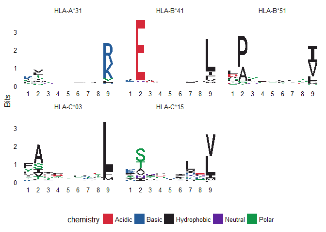

```r
a31 <- pep_dat %>% filter(label_chr == "A31") %>% pull(peptide)
b41 <- pep_dat %>% filter(label_chr == "B40") %>% pull(peptide)
b51 <- pep_dat %>% filter(label_chr == "B51") %>% pull(peptide)
c03 <- pep_dat %>% filter(label_chr == "C03") %>% pull(peptide)
c15 <- pep_dat %>% filter(label_chr == "C15") %>% pull(peptide)

logos <- list('HLA-A*31' = a31,
              'HLA-B*41' = b41,
              'HLA-B*51' = b51,
              'HLA-C*03' = c03,
              'HLA-C*15' = c15)

ggseqlogo(logos)
```

## Peptides NetMHC missed (only 15 out of 1000)

Ultimately, I don’t whether my model or NetMHC has been more accurate with my experimental data, but I thought it would be interesting to see if any of the experimentally derived peptides that NetMHC predicts as non-binders but my model predicts as binders exist in the IEDB database.

It turns out that 15 do. Only a small number, but these may be worth further investigation and indicate that NetMHC is not perfect (assuming they are true positives).

As an aside it is worth noting that in immunological terms, it’s not the number of correct identifications that is important, it’s relevant identifications that matter. By relevant I mean peptides that actually stimulate an immune response. This is why the predicted non-binders could be interesting if in fact they turned out to be actual binders and ones that the immune system react to.

Strength of binding has been used as a surrogate for immunological relevance, but it’s still somewhat an open question. An alternative hypothesis being that a continuous supply of poorly binding peptides could also stimulate the immune system. The rub being that this is tricky to observe.

However, the main point here is that models tend to inform further investigations rather than end them!

```r
# Find peptides observed in experiment, and predicted to bind by model, but
# not by NetMHC and then look to see if they are in the IEDB dataset.
validation_peps %>%
  filter(label_chr.y == "NB") %>%
  inner_join(pep_dat, by = "peptide") %>%
  select(peptide, model_class = label_chr.x, iedb_class = label_chr)
```

| peptide | model_class | iedb_class |
| --- | --- | --- |
| ATYGKPVHH | A31 | A31 |
| SDAYQTREI | B40 | B51 |
| DAPVALVVH | B51 | B51 |
| DAEMTTRMV | B51 | B51 |
| DAENAMRYI | B51 | B51 |
| DAHLGSSSV | B51 | B51 |
| TGYLNTVTV | B51 | B51 |
| DADSSERII | B51 | B51 |
| DGYVVKETI | B51 | B51 |
| DALKVTVGV | B51 | B51 |

[output cut: 5 more lines]

# Further investigations

Here a few ideas about what to do next, some from my presentation audience (thanks guys!)

- Get more training data
- Train the model with multiple different balanced random samples of the IEDB data
- Try iterated cross validation
- Add another feature i.e. binding affinity as per NetMHC
- Compare with unsupervised learning methods e.g. clustering

# Summary

- You can build a deep learning model in 20 or so lines of R code.
- Obtaining and preparing training data requires significantly more work and more code.

slides: http://ab604.github.io/docs/mhc_tensorflow_presentation.html

repo: https://github.com/ab604/mhc_tensorflow

email: ab604[at]soton.ac.uk

twitter: [@alistair604](https://twitter.com/alistair604)